# Рекомендации

# Что будет в этом модуле

- проекты с рекомендациями по данным Амазон
- сети
- тексты
- разные подходы к построению рекомендаций
- все ограничено лишь вашими способностями и фантазией

# Организация работы

- групповая работа
- часть отчетности индивидуальная
- контрольные точки (milestones)
- презентации (промежуточные и итоговые)

# План работы

- (до следующей недели) разбиение по командам
- встреча (очно или виртуально) команды
- знакомство с данными
- разработка и обсуждение идей проекта
- распределение обязанностей
- разработка и обсуждение плана
- первые варианты рекомендательных систем
- промежуточная презентация
- интеграция дополнительных данных
- отчеты
- итоговые презентации

# Amazon

- рекомендации в Amazon
- www.amazon.com
- зачем рекомендации? А как же “физические”, “реальные” магазины?

# Рекомендации фильмов

- на основе чего (features) можно рекомендовать фильмы?
- схожесть фильмов
- [Кинопоиск](https://www.kinopoisk.ru/)
- данные Amazon.com о фильмах

# Не только характеристики

- Выделить полезные характеристики сложно
- Сервисы агрегации мнений
  - https://www.rottentomatoes.com/
  - http://www.metacritic.com/
- Персонализация: коллаборативная фильтрация
- [Кинопоиск](https://www.kinopoisk.ru/recommend/)
- Amazon: явные и неявные оценки

# Качество рекомендаций: RMSE

- root-mean-square error (корень среднеквадратичной ошибки) – насколько наше предсказание отличается от реальности

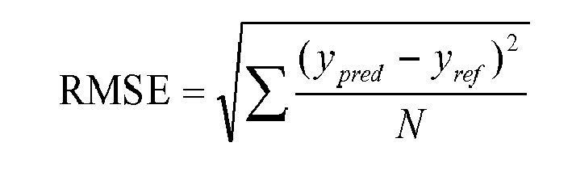

# Качество рекомендаций

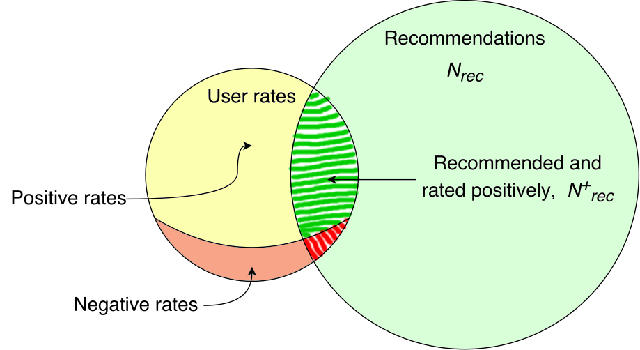

# ROC-кривая и AUC

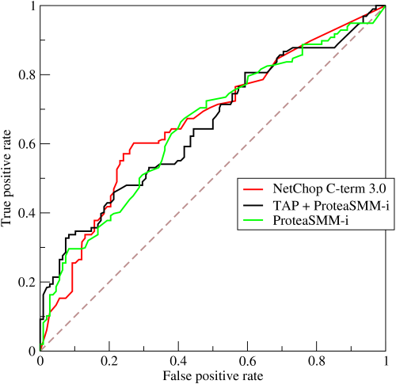

# Пример сравнения качества

[figure not shown]

# Обратно к текстам

- какие тексты нам помогут при рекомендации фильмов?
- tf-idf
- жанры
- темы

Хотим выделить темы автоматически. Как?

# Тематическое моделирование: задача

- Имеется коллекция документов. Хотим обнаружить «темы», из которых она сформирована.

Предположим:

- Каждый документ представляет собой смесь тем.
- «Тема» — набор слов, которые могут с разными вероятностями употребляться при обсуждении данной темы.

# Тематическое моделирование: свойства

- У документа может быть несколько тем.
- У каждого слова — одна тема.
- У каждого документа в коллекции — свое распределение тем (в одном документе представлены только некоторые темы коллекции).

# Тематическое моделирование: пример

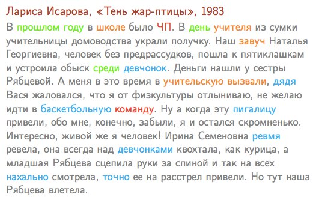

# Тематическое моделирование: пример

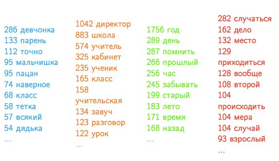

# Дополнительные данные

- [IMDb](http://www.imdb.com/)
- [MovieLens](https://movielens.org/)

# Полезные ссылки

- [Рекомендации](http://infolab.stanford.edu/~ullman/mmds/ch9.pdf)
- [Netflix](http://techblog.netflix.com/2012/04/netflix-recommendations-beyond-5-stars.html)
- [Тематическое моделирование на отзывах Amazon](http://kldavenport.com/topic-modeling-amazon-reviews/)